# Junior_DS_position_Assignment_A_Kochhar_upload

### ======================================================

### ======================================================

##### Name: Akshay Kochhar

##### Email: akshay.college2018@gmail.com

##### Created: 3rd Jan, 2021

##### ===========================================================================

##### Q1. Predict the product tier from the information given in the other columns

##### ===========================================================================

```python
#==============================================================================
# Import Required Packages
#==============================================================================
import os
import numpy as np                # To perform numerical operations
import pandas as pd               # To work with dataframes
import seaborn as sns             # To visualize data
%matplotlib qt
import string                     # To work with string
import re                         # to perform regular expression operations


# for plotting
import matplotlib.pyplot as plt
%matplotlib inline
```

```python
#==============================================================================
# Setting Dimensions of plots
#==============================================================================
sns.set(rc={'figure.figsize':(11.7,8.27)})

# to display all the columns of the dataframe in the notebook
pd.pandas.set_option('display.max_columns', None)
```

```python
#==============================================================================
# Importing Data
#==============================================================================

# Set Base Path
base_path = 'C:/Users/aksha/Desktop/Junir_DS/Junior_Data_Scientist_Akshay_Kochhar/'
file_name = 'AS24_Case_Study_Data.csv'

# Set Directory
# os.chdir(base_path)      # Use to change the current working directory

data_org = pd.read_csv(base_path+file_name)

# Creating a copy of original data
data_copy = data_org.copy()

# To check how the date looks
data_copy.head()
```

|  | article_id | product_tier | make_name | price | first_zip_digit | first_registration_year | created_date | deleted_date | search_views | detail_views | stock_days | ctr |
| --- | --- | --- | --- | --- | --- | --- | --- | --- | --- | --- | --- | --- |
| 0 | 350625839 | Basic | Mitsubishi | 16750 | 5 | 2013 | 24.07.18 | 24.08.18 | 3091.0 | 123.0 | 30 | 0.0378033 |
| 1 | 354412280 | Basic | Mercedes-Benz | 35950 | 4 | 2015 | 16.08.18 | 07.10.18 | 3283.0 | 223.0 | 52 | 0.067925678 |
| 2 | 349572992 | Basic | Mercedes-Benz | 11950 | 3 | 1998 | 16.07.18 | 05.09.18 | 3247.0 | 265.0 | 51 | 0.081613797 |
| 3 | 350266763 | Basic | Ford | 1750 | 6 | 2003 | 20.07.18 | 29.10.18 | 1856.0 | 26.0 | 101 | 0.014008621 |
| 4 | 355688985 | Basic | Mercedes-Benz | 26500 | 3 | 2014 | 28.08.18 | 08.09.18 | 490.0 | 20.0 | 12 | 0.040816327 |

#### ==============================================================================

#### **Exploratory data analysis:**

#### ==============================================================================

Some of the steps performed in data analysis are as follows:

1. Getting to know the data.
2. Data Preprocessing (Missing values).
3. Check unique values.
4. Check duplicate values.

```python
#==============================================================================
# Getting to know the data
#==============================================================================

# To check variables' data type
print(data_copy.info())
```

```
<class 'pandas.core.frame.DataFrame'>
RangeIndex: 78321 entries, 0 to 78320
Data columns (total 12 columns):
 #   Column                   Non-Null Count  Dtype
---  ------                   --------------  -----
 0   article_id               78321 non-null  int64
 1   product_tier             78321 non-null  object
 2   make_name                78321 non-null  object
 3   price                    78321 non-null  int64
 4   first_zip_digit          78321 non-null  int64
 5   first_registration_year  78321 non-null  int64
 6   created_date             78321 non-null  object
 7   deleted_date             78321 non-null  object
 8   search_views             78311 non-null  float64
 9   detail_views             78311 non-null  float64
 10  stock_days               78321 non-null  int64
 11  ctr                      78297 non-null  object
dtypes: float64(2), int64(5), object(5)
memory usage: 7.2+ MB
None
```

From below table we can check following things:

1. Seven columns are of type float/int and five columns are of type object.
2. There are missing values in column 'search_views', 'detail_views' and 'ctr'
3. Column 'ctr' would have values in incorrect format too, that is why the format is object type,but it has to be of float data type.

```python
#==============================================================================
# Check for missing values
#==============================================================================

data_copy.isnull()

print('Data columns with null values:\n \n', data_copy.isnull().sum())
# There are missing values in 3 columns.
```

```
Data columns with null values:

 article_id                  0
product_tier                0
make_name                   0
price                       0
first_zip_digit             0
first_registration_year     0
created_date                0
deleted_date                0
search_views               10
detail_views               10
stock_days                  0
ctr                        24
dtype: int64
```

```python
# Summary of numerical variables
summary_num = data_copy.describe()
print(summary_num)
```

```
         article_id          price  first_zip_digit  first_registration_year  \
count  7.832100e+04   78321.000000     78321.000000             78321.000000
mean   3.574869e+08   15067.655316         4.632117              2011.089465
std    5.076572e+06   16374.497606         2.354275                 6.538395
min    3.472324e+08       1.000000         1.000000              1924.000000
25%    3.536387e+08    5750.000000         3.000000              2008.000000
50%    3.585480e+08   10900.000000         5.000000              2013.000000
75%    3.614817e+08   18890.000000         7.000000              2015.000000
max    3.647040e+08  249888.000000         9.000000              2106.000000

        search_views  detail_views    stock_days
count   78311.000000  78311.000000  78321.000000
mean     2297.502522     93.469870     35.986262
std      6339.034423    228.025588     32.214835
min         0.000000      0.000000     -3.000000
25%       367.000000     13.000000     10.000000
50%       920.000000     36.000000     25.000000
75%      2234.000000     94.000000     55.000000
max    608754.000000  13926.000000    127.000000
```

Following points were observed from numerical variable summary:

1. There are outliners in column "Price","search_views","detail_views" and "stock_days", as all of them are right skewed. (mean > median)
2. The price cannot be 1, and stock_days cannot be -ve value.
3. The first_registration_year can not be in future (2106) or value above 2020. Therefore, I have to check the presence of outliners.

```python
# Summary of categorical variables
summary_cate = data_copy.describe(include = "O")
print(summary_cate)
```

```
       product_tier   make_name created_date deleted_date    ctr
count         78321       78321        78321        78321  78297
unique            3          91           35          273  46925
top           Basic  Volkswagen     16.11.18     01.12.18      0
freq          75421        9430         3442          947   1244
```

Following points were observed from categorical variable summary:

1. The categorical variable 'product_tier' and "make_name" seems ohkey, but I have to check for the presence of special characters.
2. The variable 'created_date' and 'deleted_date' need to be formatted in date format, and ctr in float datatype. Therefore, I have to check the presence of special characters.

```python
#==============================================================================
# Cleaning and formatting all data column
#==============================================================================

# visualise and cleaning article_id data
#print(data_copy['article_id'].shape)
#demogrphic_data.head()
#print(data_copy['article_id'].describe())

#Check and Correct article_id Column
data_copy['article_id'].value_counts()
```

```
359772384    2
360768628    2
360768627    2
364638423    2
350214315    2
            ..
364332290    1
359232772    1
358552840    1
358548746    1
348782592    1
Name: article_id, Length: 78305, dtype: int64
```

There are some duplicate article_ids becuase there are 78305 unique values out of 78321 total values which accounts to **0.02%** of total values.

Further, we have to investigate if the articles id's have same data or different values.

```python
#==============================================================================
#==============================================================================

#Check Duplicated Values in article_id column
duplicte_article_ID = data_copy[data_copy['article_id'].duplicated(keep='first')]

# make a list of the client IDs which are duplicate
duplicte_article_ID_lst = [var for var in duplicte_article_ID['article_id']]

# print the duplicate rows to analyse
# for var in duplicte_article_ID_lst:
#     print(data_copy[data_copy['article_id'] == var])
#     print(" ")

# Removing Duplicate Records
data_copy.drop_duplicates(subset ="article_id",keep = 'first', inplace = True)
print(data_copy.shape)
#16 Duplicate Records dropped

# We can leave other columns for checking duplicate values as they are continuous variables

#==============================================================================
#==============================================================================
```

```
(78305, 12)
```

```python
### visualise and cleaning product_tier data
# print(data_copy['product_tier'].shape)
# print(data_copy['product_tier'].describe())

### Check and Correct product_tier Column
# data_copy['product_tier'].unique()

### product_tier data seems to be correct

#==============================================================================
#==============================================================================

### visualise and cleaning make_name data
# print(data_copy['make_name'].shape)
# print(data_copy['make_name'].describe())

### Check and Correct make_name Column
# data_copy['make_name'] = data_copy['make_name'].str.capitalize()
# data_copy['make_name'].unique()

### make_name data seems to be correct

#==============================================================================
#==============================================================================

### visualise and cleaning created_date data
# print(data_copy['created_date'].shape)
# print(data_copy['created_date'].describe())

### Check and Correct created_date Column
# data_copy['created_date'].unique()

### created_date data seems to be correct

#==============================================================================
#==============================================================================

### visualise and cleaning deleted_date data
# print(data_copy['deleted_date'].shape)
# print(data_copy['deleted_date'].describe())

### Check and Correct deleted_date Column
# data_copy['deleted_date'].unique()

### deleted_date data seems to be correct

#==============================================================================
#==============================================================================

### visualise and cleaning ctr data
# print(data_copy['ctr'].shape)
# print(data_copy['ctr'].describe())
#data_copy['ctr'].tail()

### Check and Correct ctr Column
# data_copy['ctr'].unique()
# data_copy['ctr'] = data_copy['ctr'].astype(float)

### Why converting from object to float, I got to knot that there are values in the form '27.624.309.392.265.100'
### and '01. April' which is causing trouble

### print the values which are incorrect in 'ctr' column
val_list = []
for var in data_copy['ctr']:
    if (len(str(var))>12 or re.search(r"[a-zA-z]+",str(var))):
        val_list.append(var)

print(val_list)

### Removing the values in incorrect format and replacing them with a flag (9.9999999999)
for var in val_list:
    data_copy['ctr'] = data_copy['ctr'].str.replace(str(var),'9.9999999999')


### Changing the format of ctr column
data_copy['ctr'] = data_copy['ctr'].astype(float)

#==============================================================================
#==============================================================================
```

[output not shown]

```python
### formatting first_registration_year data

data_copy['first_registration_year_dt'] = pd.to_datetime(data_copy.first_registration_year,errors='coerce',yearfirst=True,format='%Y')

data_copy['first_registration_year_dt_yr'] = data_copy['first_registration_year_dt'].dt.year

#==============================================================================
#==============================================================================

### formatting created_date data

data_copy['created_date_dt'] = pd.to_datetime(data_copy.created_date,errors='coerce',dayfirst=True)

#==============================================================================
#==============================================================================

### formatting deleted_date data

data_copy['deleted_date_dt'] = pd.to_datetime(data_copy.deleted_date,errors='coerce',dayfirst=True)

#==============================================================================
#==============================================================================

### Calculate Stock Days from created_date and deleted_date

data_copy['stock_days_dt'] = data_copy['deleted_date_dt'] - data_copy['created_date_dt']

#==============================================================================
#==============================================================================

### Checking value for ctr if I create another column division of given columns
data_copy['ctr_calc'] = (data_copy['detail_views']/data_copy['search_views'])

data_copy.head()
```

|  | article_id | product_tier | make_name | price | first_zip_digit | first_registration_year | created_date | deleted_date | search_views | detail_views | stock_days | ctr | first_registration_year_dt | first_registration_year_dt_yr | created_date_dt | deleted_date_dt | stock_days_dt | ctr_calc |
| --- | --- | --- | --- | --- | --- | --- | --- | --- | --- | --- | --- | --- | --- | --- | --- | --- | --- | --- |
| 0 | 350625839 | Basic | Mitsubishi | 16750 | 5 | 2013 | 24.07.18 | 24.08.18 | 3091.0 | 123.0 | 30 | 0.037803 | 2013-01-01 | 2013 | 2018-07-24 | 2018-08-24 | 31 days | 0.039793 |
| 1 | 354412280 | Basic | Mercedes-benz | 35950 | 4 | 2015 | 16.08.18 | 07.10.18 | 3283.0 | 223.0 | 52 | 0.067926 | 2015-01-01 | 2015 | 2018-08-16 | 2018-10-07 | 52 days | 0.067926 |
| 2 | 349572992 | Basic | Mercedes-benz | 11950 | 3 | 1998 | 16.07.18 | 05.09.18 | 3247.0 | 265.0 | 51 | 0.081614 | 1998-01-01 | 1998 | 2018-07-16 | 2018-09-05 | 51 days | 0.081614 |
| 3 | 350266763 | Basic | Ford | 1750 | 6 | 2003 | 20.07.18 | 29.10.18 | 1856.0 | 26.0 | 101 | 0.014009 | 2003-01-01 | 2003 | 2018-07-20 | 2018-10-29 | 101 days | 0.014009 |
| 4 | 355688985 | Basic | Mercedes-benz | 26500 | 3 | 2014 | 28.08.18 | 08.09.18 | 490.0 | 20.0 | 12 | 0.040816 | 2014-01-01 | 2014 | 2018-08-28 | 2018-09-08 | 11 days | 0.040816 |

```python
### Chekcing information related to data for further processing
print(data_copy.info())
```

```
<class 'pandas.core.frame.DataFrame'>
Int64Index: 78305 entries, 0 to 78320
Data columns (total 18 columns):
 #   Column                         Non-Null Count  Dtype
---  ------                         --------------  -----
 0   article_id                     78305 non-null  int64
 1   product_tier                   78305 non-null  object
 2   make_name                      78305 non-null  object
 3   price                          78305 non-null  int64
 4   first_zip_digit                78305 non-null  int64
 5   first_registration_year        78305 non-null  int64
 6   created_date                   78305 non-null  object
 7   deleted_date                   78305 non-null  object
 8   search_views                   78295 non-null  float64
 9   detail_views                   78295 non-null  float64
 10  stock_days                     78305 non-null  int64
 11  ctr                            78281 non-null  float64
 12  first_registration_year_dt     78305 non-null  datetime64[ns]
 13  first_registration_year_dt_yr  78305 non-null  int64
 14  created_date_dt                78305 non-null  datetime64[ns]
 15  deleted_date_dt                78305 non-null  datetime64[ns]
 16  stock_days_dt                  78305 non-null  timedelta64[ns]
 17  ctr_calc                       78281 non-null  float64
dtypes: datetime64[ns](3), float64(4), int64(6), object(4), timedelta64[ns](1)
memory usage: 11.4+ MB
None
```

```python
#==============================================================================
# Generally checking missing values in formatted columns
#==============================================================================

### Check for missing values
data_copy.isnull()

print('Data columns with null values:\n', data_copy.isnull().sum())
### There are missing values in 3 columns.
```

```
Data columns with null values:
 article_id                        0
product_tier                      0
make_name                         0
price                             0
first_zip_digit                   0
first_registration_year           0
created_date                      0
deleted_date                      0
search_views                     10
detail_views                     10
stock_days                        0
ctr                              24
first_registration_year_dt        0
first_registration_year_dt_yr     0
created_date_dt                   0
deleted_date_dt                   0
stock_days_dt                     0
ctr_calc                         24
dtype: int64
```

```python
#==============================================================================
# Dropping columns which were not in correct format
#==============================================================================

data_copy_clean = data_copy.drop(['first_registration_year','created_date','deleted_date','ctr','stock_days'], axis=1)
data_copy_clean.head()
```

|  | article_id | product_tier | make_name | price | first_zip_digit | search_views | detail_views | first_registration_year_dt | first_registration_year_dt_yr | created_date_dt | deleted_date_dt | stock_days_dt | ctr_calc |
| --- | --- | --- | --- | --- | --- | --- | --- | --- | --- | --- | --- | --- | --- |
| 0 | 350625839 | Basic | Mitsubishi | 16750 | 5 | 3091.0 | 123.0 | 2013-01-01 | 2013 | 2018-07-24 | 2018-08-24 | 31 days | 0.039793 |
| 1 | 354412280 | Basic | Mercedes-benz | 35950 | 4 | 3283.0 | 223.0 | 2015-01-01 | 2015 | 2018-08-16 | 2018-10-07 | 52 days | 0.067926 |
| 2 | 349572992 | Basic | Mercedes-benz | 11950 | 3 | 3247.0 | 265.0 | 1998-01-01 | 1998 | 2018-07-16 | 2018-09-05 | 51 days | 0.081614 |
| 3 | 350266763 | Basic | Ford | 1750 | 6 | 1856.0 | 26.0 | 2003-01-01 | 2003 | 2018-07-20 | 2018-10-29 | 101 days | 0.014009 |
| 4 | 355688985 | Basic | Mercedes-benz | 26500 | 3 | 490.0 | 20.0 | 2014-01-01 | 2014 | 2018-08-28 | 2018-09-08 | 11 days | 0.040816 |

```python
#==============================================================================
# Writing Complete Master Data to CSV
#==============================================================================

data_copy_clean.to_csv('1_Clean_Data.csv', encoding='utf-8', index=False)
```

```python
#========================================================================================
# Missing values: Let's find out which variables of the dataset contain missing values
#========================================================================================

### Changing stock days from series to int
data_copy_clean['stock_days_dt_int'] = data_copy_clean['stock_days_dt'].dt.days

### make a list of the variables that contain missing values
vars_with_na = [var for var in data_copy_clean.columns if data_copy_clean[var].isnull().sum()>1
                and var not in ['article_id','product_tier']]

### print the variable name and the percentage of missing values
for var in vars_with_na:
    print(var, np.round(data_copy_clean[var].isnull().mean(), 6),  ' % missing values')
```

```
search_views 0.000128  % missing values
detail_views 0.000128  % missing values
ctr_calc 0.000306  % missing values
```

Our dataset contains a few variables with missing values. We need to account for this in following step, where we will engineer the variables for use in Machine Learning Models.

```python
#========================================================================================
# Check zero values: Let's find out which variables of the dataset contain zero values
#========================================================================================

### make a list of the variables that contain zero values
vars_with_zero = [var for var in data_copy_clean.columns if data_copy_clean[var].isin([0]).sum()>1
                  and var not in ['article_id','stock_days_dt_int','stock_days_dt']]

### print the variable name and the percentage of missing values
for var in vars_with_zero:
    print(var, np.round(data_copy_clean[var].isin([0]).mean(), 6),  ' % zero values')
```

```
search_views 0.000179  % zero values
detail_views 0.016065  % zero values
first_registration_year_dt 0.000332  % zero values
ctr_calc 0.015887  % zero values
```

Our dataset contains a few variables with zero values, i.e. search_views, detail_views, first_registraction_year_dt, ctr_calc. We need to account for this in following step, where we will engineer the variables for use in Machine Learning Models.

**Note:** We can use either Product_tier or detail_view as target variable in Exploratory Data Analysis (EDA). The purpose is too undertand the pattern in the data, and it can be understood from any of the variables. Therefore, for Q2, I have not shown EDA as this solves the pupose for both questions.

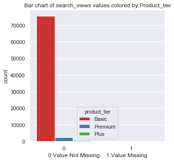

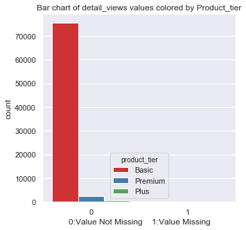

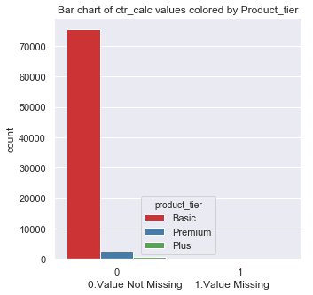

```python
#========================================================================================
# Relationship between missing values and product_tier variable
#========================================================================================

### Let's evaluate count of Product_tier for those cases where the information is missing, for each variable.

def analyse_na_value(df, var):
    df = df.copy()

    # let's make a variable that indicates 1 if the observation is missing or zero otherwise
    df[var] = np.where(df[var].isnull(), 1, 0)

    # let's calculate the observations where the information is missing or present
    plt.figure(figsize=(5,5))
    sns.countplot(x=var,hue='product_tier',data=df,palette='Set1')
    plt.title("Bar chart of " +var+ " values colored by Product_tier", fontsize=12)
    plt.xlabel("0:Value Not Missing    1:Value Missing", fontsize=12)

for var in vars_with_na:
    analyse_na_value(data_copy_clean, var)
```

We can see that there are no significant count of missing values for search_views, detail_views, ctr_calc. The missing values will be captured once we engineer these values in the following stage.

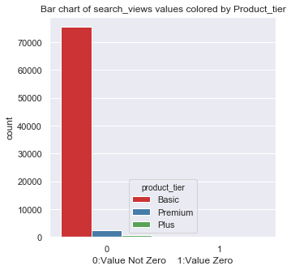

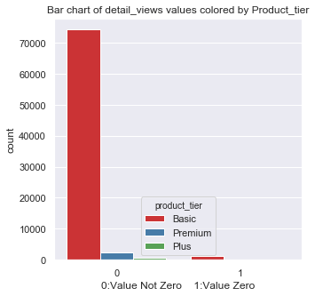

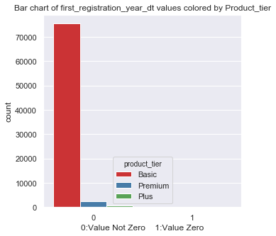

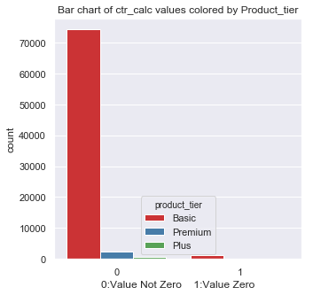

```python
#========================================================================================
# Relationship between zero values and product_tier variable
#========================================================================================

### Let's evaluate count of Product_tier for those cases where the information is zero, for each variable.

def analyse_zro_value(df, var):
    df = df.copy()

    # let's make a variable that indicates 1 if the observation is 0 or zero otherwise
    df[var] = np.where(df[var].isin([0]), 1, 0)

    # let's calculate the observations where the information is zero or otherwise
    plt.figure(figsize=(5,5))
    sns.countplot(x=var,hue='product_tier',data=df,palette='Set1')
    plt.title("Bar chart of " +var+ " values colored by Product_tier", fontsize=12)
    plt.xlabel("0:Value Not Zero    1:Value Zero", fontsize=12)

for var in vars_with_zero:
    analyse_zro_value(data_copy_clean, var)
```

```python
#========================================================================================
# Numerical variables
#========================================================================================

### Let's go ahead and find out numerical variables in the dataset

# list of numerical variables
num_vars = [var for var in data_copy_clean.columns if data_copy_clean[var].dtypes != 'O' and var not in ['first_registration_year_dt','first_registration_year_dt_yr','created_date_dt','deleted_date_dt','stock_days_dt']]

print('Number of numerical variables: ', len(num_vars))

# visualise the numerical variables
data_copy_clean[num_vars].head()
```

```
Number of numerical variables:  7
```

|  | article_id | price | first_zip_digit | search_views | detail_views | ctr_calc | stock_days_dt_int |
| --- | --- | --- | --- | --- | --- | --- | --- |
| 0 | 350625839 | 16750 | 5 | 3091.0 | 123.0 | 0.039793 | 31 |
| 1 | 354412280 | 35950 | 4 | 3283.0 | 223.0 | 0.067926 | 52 |
| 2 | 349572992 | 11950 | 3 | 3247.0 | 265.0 | 0.081614 | 51 |
| 3 | 350266763 | 1750 | 6 | 1856.0 | 26.0 | 0.014009 | 101 |
| 4 | 355688985 | 26500 | 3 | 490.0 | 20.0 | 0.040816 | 11 |

From the above view of the dataset, we notice the variable article_id, which is an indicator of the products. We will not use this variable to make our predictions, as there is one different value of the variable per each row, i.e., each product in the dataset. See below

```python
### Checking the count of values in article_id v/s total number of values in the dataset.
print('Number of Article Id labels: ', len(data_copy_clean.article_id.unique()))
print('Number of products in the Dataset: ', len(data_copy_clean))
```

```
Number of Article Id labels:  78305
Number of products in the Dataset:  78305
```

For 78305 observations, we have 78305 values that is one for each product. Therefore, we will remove this feature from the data.

```python
#========================================================================================
# Numerical variables: Discrete variables
#========================================================================================

### Let's go ahead and find which variables are discrete, i.e., show a finite number of values

#  list of discrete variables
discrete_vars = [var for var in num_vars if len(data_copy_clean[var].unique())<20 and var not in ['article_id']]

print('Number of discrete variables: ', len(discrete_vars))
```

```
Number of discrete variables:  1
```

```python
### let's visualise the discrete variables
data_copy_clean[discrete_vars].head()
```

|  | first_zip_digit |
| --- | --- |
| 0 | 5 |
| 1 | 4 |
| 2 | 3 |
| 3 | 6 |
| 4 | 3 |

We can see that these variables refer to first zip digit.

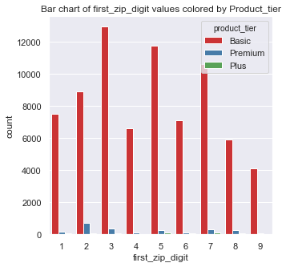

```python
### Let's go ahead and analyse discrete variables contribution to the target variable.

def analyse_discrete(df, var):
    df = df.copy()
    plt.figure(figsize=(5,5))
    sns.countplot(x=var,hue='product_tier',data=df,palette='Set1')
    plt.title("Bar chart of " +var+ " values colored by Product_tier", fontsize=12)
    #plt.xlabel("Null - 0:No ; 1:Yes", fontsize=12)

for var in discrete_vars:
    analyse_discrete(data_copy_clean,var)
```

Following points were observed from above graph:

1. We can see that there is no monotonic relationship between first_zip_digit and Product_tier.
2. first_zip_digit is a significant variable because it has contributed to the likelyhood of article being in a significant tier. With zip 3,5,7 contributed to higher likelyhood of buying a basic tier product.
3. The likelyhood of buying a Premium tier product has been found a little higher in zip digit 2,3,7 and 8.

```python
#========================================================================================
# Numerical variables: Continuous variables
#========================================================================================

### Let's go ahead and find the distribution of the continuous variables.
### We will consider all those variables that are not temporal(date) or discrete
### in our dataset.

# list of continuous variables
cont_vars = [var for var in num_vars if var not in discrete_vars+['article_id']]

print('Number of continuous variables: ', len(cont_vars))
```

```
Number of continuous variables:  5
```

```python
### let's visualise the continuous variables
data_copy_clean[cont_vars].head()
```

|  | price | search_views | detail_views | ctr_calc | stock_days_dt_int |
| --- | --- | --- | --- | --- | --- |
| 0 | 16750 | 3091.0 | 123.0 | 0.039793 | 31 |
| 1 | 35950 | 3283.0 | 223.0 | 0.067926 | 52 |
| 2 | 11950 | 3247.0 | 265.0 | 0.081614 | 51 |
| 3 | 1750 | 1856.0 | 26.0 | 0.014009 | 101 |
| 4 | 26500 | 490.0 | 20.0 | 0.040816 | 11 |

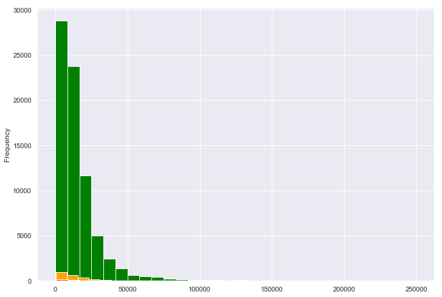

[figure not shown]

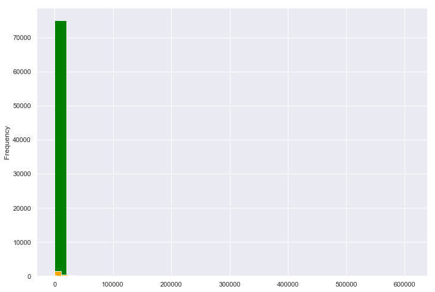

[figure not shown]

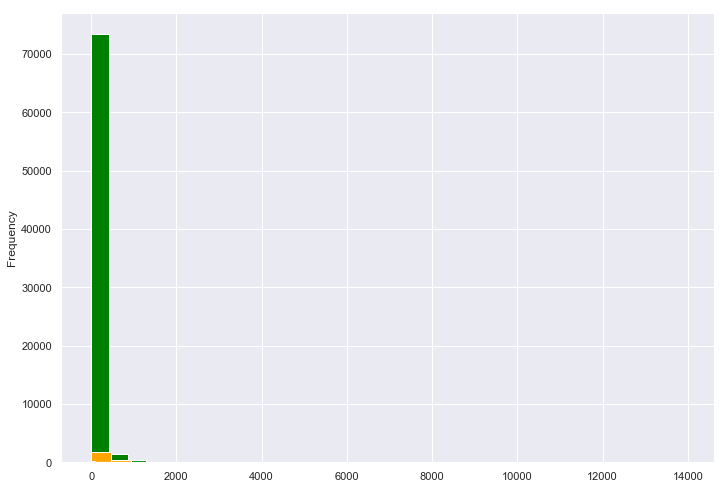

[figure not shown]

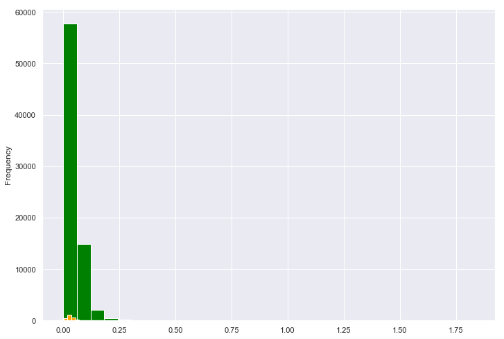

[figure not shown]

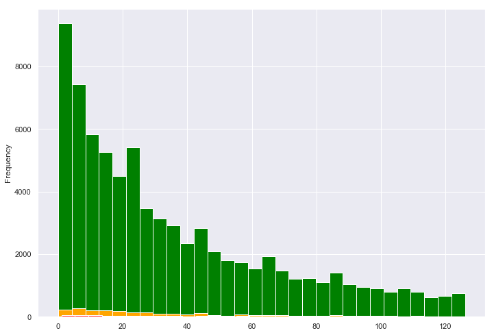

[figure not shown]

```python
### Let's go ahead and analyse the distributions of these variables with target variable
def analyse_continous(df, var):
    df = df.copy()
    #df[var].hist(bins=20)
    df[df['product_tier']=="Basic"][var].plot.hist(bins=30,color='green',label='Basic')
    df[df['product_tier']=="Premium"][var].plot.hist(bins=30, color='orange',label='Premium')
    df[df['product_tier']=="Plus"][var].plot.hist(bins=30, color='red',label='Plus')
    plt.figure(figsize=(3,3))
    plt.xlabel(var)
    plt.title(var)
    plt.show()

for var in cont_vars:
    analyse_continous(data_copy_clean, var)
```

The understanding from the distribution of these plots is as follows:

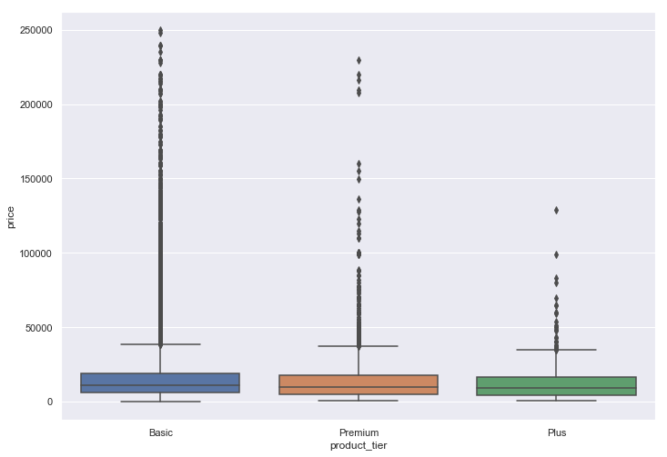

[figure not shown]

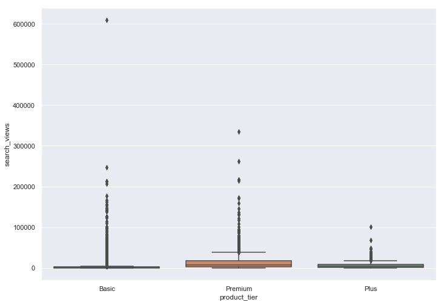

[figure not shown]

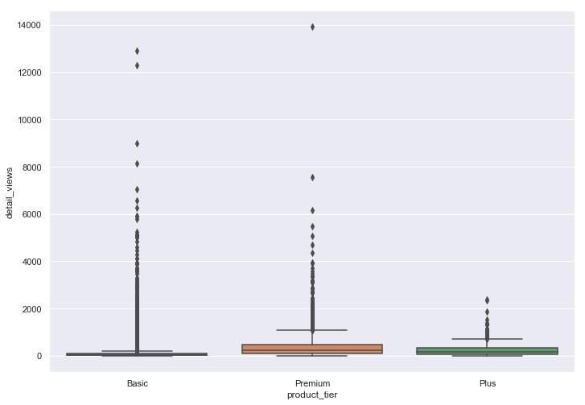

[figure not shown]

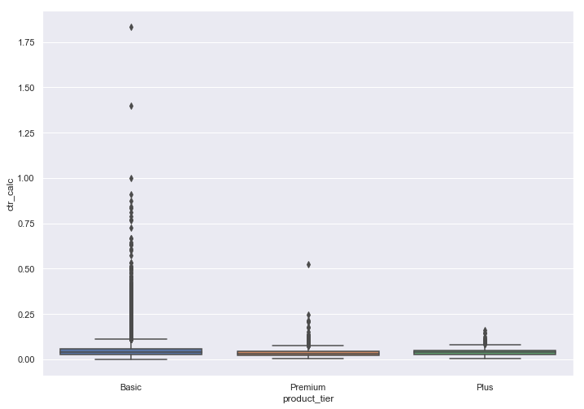

[figure not shown]

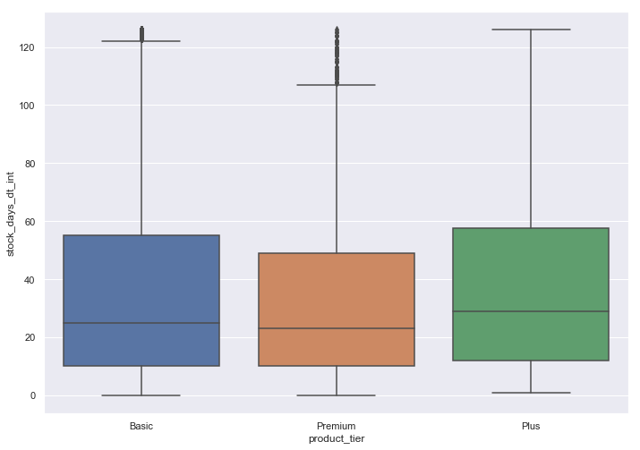

[figure not shown]

```python
#========================================================================================
# Checking Outliers
#========================================================================================

# let's make boxplots to visualise outliers in the continuous variables

def find_outliers(df, var):
    df = df.copy()
    sns.boxplot(x=df['product_tier'],y=df[var])
    plt.xlabel("product_tier")
    plt.figure(figsize=(3,3))
    plt.title(var)
    plt.ylabel(var)
    plt.show()

for var in cont_vars:
    find_outliers(data_copy_clean, var)
```

```python
#==============================================================================
# Categorical variables
#==============================================================================

### Let's go ahead and analyse the categorical variables present in the dataset.

cat_vars = [var for var in data_copy_clean.columns if data_copy_clean[var].dtypes=='O' and var not in ['product_tier'] ]

print('Number of categorical variables: ', len(cat_vars))
```

```
Number of categorical variables:  1
```

```python
### let's visualise the values of the categorical variables
data_copy_clean[cat_vars].head()
```

|  | make_name |
| --- | --- |
| 0 | Mitsubishi |
| 1 | Mercedes-benz |
| 2 | Mercedes-benz |
| 3 | Ford |
| 4 | Mercedes-benz |

```python
#==============================================================================
# Cardinality: Number of labels in a column
#==============================================================================

### Let's evaluate how many different categories are present in each of the variables.

for var in cat_vars:
    print(var, len(data_copy_clean[var].unique()), ' categories')
```

```
make_name 91  categories
```

product_tier categorical variables show low cardinality except make_name; this means that make_name has large number of different labels. We need to tackle high cardinality in following steps as it can lead too **over-fitting** of the model.

```python
#==============================================================================
# Rare labels
#==============================================================================

### Let's go ahead and investigate now if there are labels that are present only
### in small proportion, i.e., below 1% of data

def analyse_rare_labels(df, var, rare_perc):
    df = df.copy()
    tmp = df.groupby(var)['product_tier'].count() / len(df)
    return tmp[tmp<rare_perc]

for var in cat_vars:
    print(analyse_rare_labels(data_copy_clean, var, 0.01))
    print()
```

```
make_name
Abarth        0.000268
Ac            0.000013
Aixam         0.000306
Alfa romeo    0.006794
Alpina        0.000089
                ...
Tata          0.000013
Tesla         0.001073
Triumph       0.000485
Trucks-lkw    0.000230
Tvr           0.000013
Name: product_tier, Length: 70, dtype: float64
```

Around 70 labels in make_name are present in less than 1% of the data. **Labels that are under-represented in the dataset tend to cause over-fitting of machine learning models.**